# **Analyzing the Impact of COVID-19 on New Orleans Education**

### Shania Phillips and Maria Aponte Rosero

### https://sphil5.github.io/

```python
%cd /content
!git clone https://github.com/sphil5/sphil5.github.io.git
```

```
/content
fatal: destination path 'sphil5.github.io' already exists and is not an empty directory.
```

```python
from google.colab import drive
drive.mount('/content/drive')
import pandas as pd
import numpy as np
import matplotlib.pyplot as plt
import seaborn as sns
```

## Project Goals

The COVID-19 pandemic caused widespread disruptions to daily life, including significant changes to how students experienced education. This project aims to examine the impact of COVID-19 on public school education in New Orleans, Louisiana. Specifically, it analyzes changes in school performance scores (SPS) and student progress indices across multiple schools, comparing trends from the pre-pandemic period (2016–2019) to the post-pandemic years (2020–2025). In addition to this, the project also explores variation across schools to determine whether recovery has been uniform or uneven. By evaluating both overall performance and measures of student growth, this analysis seeks to identify the extent of academic disruption and assess patterns of recovery across schools over time.

**Research Questions:**

1. Is student progress index a significant predictor of school performance score (SPS)?
2. Did COVID-19 cause a statistically significant decline in average school performance scores?

### Collaboration Plan

For this project, we plan to meet once a week to discuss progress, refine our research questions, and plan the next steps of our analysis. Between meetings, we will communicate via text to address questions and provide support as needed. We will use a shared GitHub repository to manage our code and data, allowing us to track changes, organize files, and ensure that both collaborators are working with the most up-to-date version of the project. Responsibilities will be divided across tasks such as data cleaning, visualization, and interpretation, with us both contributing to each stage of the analysis.

## Dataset 1: Pre-COVID Data

The first dataset used in this analysis consists of school performance score (SPS) data obtained from the [Louisiana Department of Education](https://doe.louisiana.gov/data-and-reports/performance-scores). We collected SPS datasets for the years 2016–2019, representing the pre-COVID period. Each dataset contains school-level performance metrics, including overall performance scores and related indicators used to evaluate academic achievement. To prepare the data for analysis, the individual yearly datasets were cleaned and standardized to ensure consistent column names and formats across years. These datasets were then combined into a single dataframe covering the full 2016–2019 period. This consolidated dataset allows for efficient comparison of school performance trends prior to the onset of the COVID-19 pandemic.

### Data Cleaning (ETL)

To prepare the datasets for analysis, we performed several cleaning and transformation steps to ensure consistency and usability across years:

- Standardized all column names to lowercase with underscores
- Melted wide-format yearly data into a tidy long format (one row per school per year)
- Extracted the numeric year from column names and constructed a readable `school_year` label
- Removed duplicate rows created by overlapping year columns across datasets
- Retained only the three columns needed for analysis: `school_name`, `school_year`, and `school_performance_score_sps`

```python
# Helper function to standardize column names across all yearly datasets
def clean_columns(df):
    df.columns = (
        df.columns
        .str.lower()
        .str.strip()
        .str.replace("\n", "_")
        .str.replace(" ", "_")
        .str.replace(r"[()]", "", regex=True)
    )
    return df
```

```python
import os

os.listdir('/content')
```

```
['.config',
 'dsproject.ipynb',
 'dsproject.html',
 'drive',
 'sphil5.github.io',
 'sample_data']
```

```python
# @title Cleaning the 2016 dataset:

# Load 2016 dataset and skip the empty header rows
df_2016 = pd.read_excel("/content/sphil5.github.io/data/2016-school-performance-scores.xlsx", header=2)
# Standardize column names
df_2016 = clean_columns(df_2016)
# Rename column for consistency
df_2016 = df_2016.rename(columns={"school": "school_name"})
# Convert wide format to long format
df_2016_long = pd.melt(
    df_2016,
    id_vars=["school_name"],
    value_vars=["2016_annual_sps", "2015_annual_sps"],
    var_name="year",
    value_name="school_performance_score_sps"
)
# Extract year and create school_year format
df_2016_long["year"] = df_2016_long["year"].str.extract(r"(\d{4})").astype(int)
df_2016_long["school_year"] = df_2016_long["year"].astype(str) + "-" + (df_2016_long["year"] + 1).astype(str)
# Drop temporary column
df_2016_long = df_2016_long.drop(columns=["year"])
```

```python
# @title Cleaning the 2017 dataset:

# Load 2017 dataset and skip the empty header rows
df_2017 = pd.read_excel("/content/sphil5.github.io//data/2017-school-performance-score-summary.xlsx", header=2)
# Standardize column names
df_2017 = clean_columns(df_2017)
# Rename column for consistency
df_2017 = df_2017.rename(columns={"school": "school_name"})
# Convert wide format to long format
df_2017_long = pd.melt(
    df_2017,
    id_vars=["school_name"],
    value_vars=["2017_final_sps", "2016_annual_sps"],
    var_name="year",
    value_name="school_performance_score_sps"
)
df_2017_long["year"] = df_2017_long["year"].astype(str)
# Extract year and create school_year format
df_2017_long["year"] = df_2017_long["year"].str.extract(r"(\d{4})").astype(int)
df_2017_long["school_year"] = df_2017_long["year"].astype(str) + "-" + (df_2017_long["year"] + 1).astype(str)
# Drop temporary column
df_2017_long = df_2017_long.drop(columns=["year"])
```

```python
# @title Cleaning the 2018 dataset:

# Load 2018 dataset and skip the empty header rows
df_2018 = pd.read_excel("/content/sphil5.github.io/data/2018-school-performance-scores.xlsx", header=3)
# Standardize column names
df_2018 = clean_columns(df_2018)
# Rename column for consistency
df_2018 = df_2018.rename(columns={"school": "school_name"})
# Convert wide format to long format
df_2018_long = pd.melt(
    df_2018,
    id_vars=["school_name"],
    value_vars=["2018_sps__old_formula", "2017_sps__old_formula"],
    var_name="year",
    value_name="school_performance_score_sps"
)
df_2018_long["year"] = df_2018_long["year"].astype(str)
# Extract year and create school_year format
df_2018_long["year"] = df_2018_long["year"].str.extract(r"(\d{4})").astype(int)
df_2018_long["school_year"] = df_2018_long["year"].astype(str) + "-" + (df_2018_long["year"] + 1).astype(str)
# Drop temporary column
df_2018_long = df_2018_long.drop(columns=["year"])
```

```python
# @title Cleaning the 2019 dataset:

# Load 2019 dataset and skip the empty header rows
df_2019 = pd.read_excel("/content/sphil5.github.io/data/2019-school-performance-scores.xlsx", header=3)
# Standardize column names
df_2019 = clean_columns(df_2019)
# Rename column for consistency
df_2019 = df_2019.rename(columns={"school": "school_name"})
# Convert wide format to long format
df_2019_long = pd.melt(
    df_2019,
    id_vars=["school_name"],
    value_vars=["2019_sps", "2018_sps"],
    var_name="year",
    value_name="school_performance_score_sps"
)
df_2019_long["year"] = df_2019_long["year"].astype(str)
# Extract year and create school_year format
df_2019_long["year"] = df_2019_long["year"].str.extract(r"(\d{4})").astype(int)
df_2019_long["school_year"] = df_2019_long["year"].astype(str) + "-" + (df_2019_long["year"] + 1).astype(str)
# Drop temporary column
df_2019_long = df_2019_long.drop(columns=["year"])
```

```python
# @title Combining datasets into a DataFrame:

# Combine all pre-COVID yearly DataFrames into one tidy dataset and remove duplicates
df_pre_covid = pd.concat([
    df_2016_long,
    df_2017_long,
    df_2018_long,
    df_2019_long
], ignore_index=True)
# Remove duplicate rows
df_pre_covid = df_pre_covid.drop_duplicates()
# Keep only the three columns needed for analysis
df_pre_covid = df_pre_covid[[
    "school_name",
    "school_year",
    "school_performance_score_sps"
]]

# Convert SPS to numeric, coercing any non-numeric values to NaN
df_pre_covid["school_performance_score_sps"] = pd.to_numeric(
    df_pre_covid["school_performance_score_sps"], errors="coerce"
)

# Drop rows with missing SPS values
df_pre_covid = df_pre_covid.dropna(subset=["school_performance_score_sps"])

print("Pre-COVID dataset shape:", df_pre_covid.shape)
print("\nMissing values:")
print(df_pre_covid.isna().sum())
print("\nData types:")
print(df_pre_covid.dtypes)
print("\nRecords per school year:")
print(df_pre_covid["school_year"].value_counts().sort_index())
```

```
Pre-COVID dataset shape: (7789, 3)

Missing values:
school_name                     0
school_year                     0
school_performance_score_sps    0
dtype: int64

Data types:
school_name                      object
school_year                      object
school_performance_score_sps    float64
dtype: object

Records per school year:
school_year
2015-2016    1300
2016-2017    1347
2017-2018    1298
2018-2019    2577
2019-2020    1267
Name: count, dtype: int64
```

```python
df_pre_covid.head(10)
```

|  | school_name | school_year | school_performance_score_sps |
| --- | --- | --- | --- |
| 0 | Armstrong Middle School | 2016-2017 | 66.5 |
| 1 | Branch Elementary School | 2016-2017 | 102.7 |
| 2 | Central Rayne Kindergarten School | 2016-2017 | 89.9 |
| 3 | Church Point Elementary School | 2016-2017 | 67.8 |
| 4 | Church Point High School | 2016-2017 | 82.3 |
| 5 | Church Point Middle School | 2016-2017 | 76.0 |
| 6 | Crowley High School | 2016-2017 | 91.1 |
| 7 | Crowley Middle School | 2016-2017 | 69.0 |
| 8 | Crowley Kindergarten School | 2016-2017 | 80.2 |
| 9 | North Crowley Elementary School | 2016-2017 | 80.2 |

### Pre-COVID Performance Trends

Before analyzing the impact of COVID-19, we examine school performance trends during the pre-pandemic years (2015–2019). By visualizing the trend over time, we can establish whether performance was stable, improving, or already declining before the pandemic hit. This provides a baseline for understanding how performance changed after the onset of the pandemic.

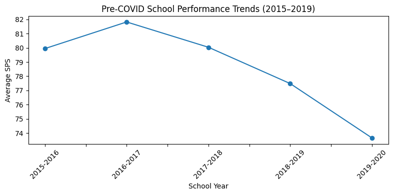

| school_year | school_performance_score_sps |
| --- | --- |
| 2015-2016 | 79.944308 |
| 2016-2017 | 81.816630 |
| 2017-2018 | 80.038444 |
| 2018-2019 | 77.484400 |
| 2019-2020 | 73.659826 |

**dtype:** float64

```python
# Calculate average SPS for each pre-COVID school year
avg_pre = (
    df_pre_covid
    .groupby("school_year")["school_performance_score_sps"]
    .mean()
    .sort_index()
)

avg_pre.plot(marker="o", figsize=(8, 4))
plt.title("Pre-COVID School Performance Trends (2015–2019)")
plt.xlabel("School Year")
plt.ylabel("Average SPS")
plt.xticks(rotation=45)
plt.tight_layout()
plt.show()

# Display values for verification
avg_pre
```

## Dataset 2: Post-COVID Data

The second dataset was obtained from [NOLA Public Schools](https://data.nolapublicschools.com/data-library/). This dataset includes key academic metrics for New Orleans public schools from 2020 onward to the most recent completed school year (2024–2025). For this analysis, we focus on school performance score (SPS) and progress index. These variables allow us to evaluate both academic outcomes and student growth in the years following COVID-19.

### Data Cleaning (ETL)

We cleaned up this dataset by performing the following steps:

- Standardized column names to lowercase with underscores
- Renamed the SPS column to match the pre-COVID dataset for easy concatenation
- Removed rows with missing school performance scores
- Dropped columns that were almost entirely missing (`nola-ps_spri`, `nola-ps_spri_letter_grade`)
- Converted SPS and progress index to numeric types
- Verified data types and remaining missing values

```python
# Load dataset
df_postcovid = pd.read_excel("/content/sphil5.github.io/data/academic_metrics.xlsx")
df_postcovid.head()
```

|  | School Name | School Year | Site Code | School Type | Grade Configuration | Subgroup | Domain | % Attaining Top Growth | NOLA-PS SPRI | NOLA-PS SPRI Letter Grade | School Performance Score (SPS) | SPS Letter Grade | Assessment Index | NOLA-PS Assessment Index | Assessment Index Letter Grade | Progress Index | Progress Index Letter Grade | NOLA-PS Progress Index | NOLA-PS Top Growth % | Graduation Rate |
| --- | --- | --- | --- | --- | --- | --- | --- | --- | --- | --- | --- | --- | --- | --- | --- | --- | --- | --- | --- | --- |
| 0 | International School of Louisiana | 2020-2021 | 331001 | Type 2 | K-8 | All Students | Quality | 48.0 | NaN | NaN | 73.6 | NaN | 59.0 | NaN | NaN | 90.2 | NaN | 83.3 | 44.0 | NaN |
| 1 | International School of Louisiana | 2021-2022 | 331001 | Type 2 | K-8 | All Students | Quality | 48.0 | NaN | NaN | 80.0 | B | 66.7 | 60.3 | C | 89.2 | B | 86.0 | 46.0 | NaN |
| 2 | International School of Louisiana | 2022-2023 | 331001 | Type 2 | K-8 | All Students | Quality | 52.0 | NaN | NaN | 78.3 | B | 67.8 | 42.7 | C | 95.6 | A | 94.0 | 51.0 | NaN |
| 3 | International School of Louisiana | 2023-2024 | 331001 | Type 2 | K-8 | All Students | Quality | 51.0 | NaN | NaN | 84.2 | B | 72.8 | 51.2 | C | 96.8 | A | 95.6 | 52.0 | NaN |
| 4 | International School of Louisiana | 2024-2025 | 331001 | Type 2 | K-8 | All Students | Quality | 50.0 | NaN | NaN | 84.4 | B | 73.5 | NaN | C | 96.4 | A | NaN | NaN | NaN |

### Data Cleaning (ETL)

We cleaned up this dataset by performing a few different tasks.

First, we changed the column names to make them easier to reference in code.

Next, we removed any missing data from the school performance scores column to focus on the information present for our statistics and visualization.

Lastly, we got rid of columns that had most of its data missing since it would not be as useful to our investigation.

```python
# Standardize column names to lowercase with underscores
df_postcovid.columns = df_postcovid.columns.str.lower().str.replace(" ", "_")

# Rename the SPS column to match the pre-COVID dataframe
df_postcovid = df_postcovid.rename(columns={
    "school_performance_score_(sps)": "school_performance_score_sps"
})

# Drop rows with missing performance scores
df_postcovid = df_postcovid.dropna(subset=["school_performance_score_sps"])

# Drop columns with the majority of data missing
df_postcovid = df_postcovid.drop(columns=[
    "nola-ps_spri",
    "nola-ps_spri_letter_grade"
], errors="ignore")  # errors='ignore' prevents crash if columns are already absent

# Convert key numeric columns
df_postcovid["school_performance_score_sps"] = pd.to_numeric(
    df_postcovid["school_performance_score_sps"], errors="coerce"
)
if "progress_index" in df_postcovid.columns:
    df_postcovid["progress_index"] = pd.to_numeric(
        df_postcovid["progress_index"], errors="coerce"
    )

print("Post-COVID dataset shape:", df_postcovid.shape)
print("\nMissing values:")
print(df_postcovid.isna().sum())
print("\nData types:")
print(df_postcovid.dtypes)
```

```
Post-COVID dataset shape: (352, 18)

Missing values:
school_name                        0
school_year                        0
site_code                          0
school_type                        0
grade_configuration                0
subgroup                           0
domain                             0
%_attaining_top_growth             2
school_performance_score_sps       0
sps_letter_grade                  65
assessment_index                  19
nola-ps_assessment_index         138
assessment_index_letter_grade     81
progress_index                     2
progress_index_letter_grade       66
nola-ps_progress_index            73
nola-ps_top_growth_%              73
graduation_rate                  222
dtype: int64

Data types:
school_name                       object
school_year                       object
site_code                         object
school_type                       object
grade_configuration               object
subgroup                          object
domain                            object
%_attaining_top_growth           float64
school_performance_score_sps     float64
sps_letter_grade                  object
assessment_index                 float64
nola-ps_assessment_index         float64
assessment_index_letter_grade     object
progress_index                   float64
progress_index_letter_grade       object
nola-ps_progress_index           float64
nola-ps_top_growth_%             float64
graduation_rate                   object
dtype: object
```

```python
df_postcovid.head(10)
```

|  | school_name | school_year | site_code | school_type | grade_configuration | subgroup | domain | %_attaining_top_growth | school_performance_score_sps | sps_letter_grade | assessment_index | nola-ps_assessment_index | assessment_index_letter_grade | progress_index | progress_index_letter_grade | nola-ps_progress_index | nola-ps_top_growth_% | graduation_rate |
| --- | --- | --- | --- | --- | --- | --- | --- | --- | --- | --- | --- | --- | --- | --- | --- | --- | --- | --- |
| 0 | International School of Louisiana | 2020-2021 | 331001 | Type 2 | K-8 | All Students | Quality | 48.0 | 73.6 | NaN | 59.0 | NaN | NaN | 90.2 | NaN | 83.3 | 44.0 | NaN |
| 1 | International School of Louisiana | 2021-2022 | 331001 | Type 2 | K-8 | All Students | Quality | 48.0 | 80.0 | B | 66.7 | 60.3 | C | 89.2 | B | 86.0 | 46.0 | NaN |
| 2 | International School of Louisiana | 2022-2023 | 331001 | Type 2 | K-8 | All Students | Quality | 52.0 | 78.3 | B | 67.8 | 42.7 | C | 95.6 | A | 94.0 | 51.0 | NaN |
| 3 | International School of Louisiana | 2023-2024 | 331001 | Type 2 | K-8 | All Students | Quality | 51.0 | 84.2 | B | 72.8 | 51.2 | C | 96.8 | A | 95.6 | 52.0 | NaN |
| 4 | International School of Louisiana | 2024-2025 | 331001 | Type 2 | K-8 | All Students | Quality | 50.0 | 84.4 | B | 73.5 | NaN | C | 96.4 | A | NaN | NaN | NaN |
| 5 | New Orleans Center for Creative Arts | 2020-2021 | 334001 | Type 2 | HS | All Students | Quality | 50.0 | 109.7 | NaN | 91.1 | NaN | NaN | 100.5 | NaN | 80.3 | 44.0 | >95% |
| 6 | New Orleans Center for Creative Arts | 2021-2022 | 334001 | Type 2 | HS | All Students | Quality | 49.0 | 104.6 | A | 84.8 | 40.4 | B | 96.5 | A | 81.0 | 46.0 | 91.7 |
| 7 | New Orleans Center for Creative Arts | 2022-2023 | 334001 | Type 2 | HS | All Students | Quality | 43.0 | 96.5 | A | 88.2 | 39.2 | B | 92.4 | A | 86.1 | 51.0 | 88.7 |
| 8 | New Orleans Center for Creative Arts | 2023-2024 | 334001 | Type 2 | HS | All Students | Quality | 44.0 | 91.3 | A | 87.9 | 51.2 | B | 91.2 | A | 87.7 | 52.0 | >95% |
| 9 | New Orleans Center for Creative Arts | 2024-2025 | 334001 | Type 2 | HS | All Students | Quality | 46.0 | 103.5 | A | 86.3 | NaN | B | 92.0 | A | NaN | NaN | >95% |

### Interesting Statistics

Key statistics from the post-COVID dataset include:

- There are 75 unique schools included in this dataset.
- The average performance score has increased since the 2020–2021 school year, rising from approximately 64.53 to 74.67.
- Benjamin Franklin High School had the highest performance score of 133.9, occurring in the 2024–2025 school year.
- Thurgood Marshall had the lowest performance score of 40.9, occurring in the 2020–2021 school year.

These statistics inform us of when the highest and lowest performance scores occurred, as well as the overall average across years. This gives us an initial indication of performance score recovery trends since the pandemic.

```python
# Number of unique schools (each school appears multiple times across years)
num_schools = df_postcovid["school_name"].nunique()

# Average SPS per school year
avg_performance_per_year = df_postcovid.groupby("school_year")["school_performance_score_sps"].mean()

# School with the highest and lowest SPS
max_score = df_postcovid.loc[df_postcovid["school_performance_score_sps"].idxmax()]
min_score = df_postcovid.loc[df_postcovid["school_performance_score_sps"].idxmin()]

print("Number of schools:", num_schools)
print("\nAverage performance score per year:")
print(avg_performance_per_year.to_string())
print("\nHighest SPS — School:", max_score["school_name"], "| Year:", max_score["school_year"], "| Score:", max_score["school_performance_score_sps"])
print("Lowest SPS  — School:", min_score["school_name"], "| Year:", min_score["school_year"], "| Score:", min_score["school_performance_score_sps"])
```

```
Number of schools: 75

Average performance score per year:
school_year
2020-2021    64.532308
2021-2022    66.477143
2022-2023    70.573239
2023-2024    74.153425
2024-2025    74.668493

Highest SPS — School: Benjamin Franklin High School | Year: 2024-2025 | Score: 133.9
Lowest SPS  — School: Success @ Thurgood Marshall | Year: 2020-2021 | Score: 40.9
```

### Post-COVID Performance Trends

This line graph shows the average School Performance Score for each year from 2020–2021 onward. It focuses the view on the recovery period, allowing us to assess whether and how quickly scores rebounded after the initial COVID-19 disruption.

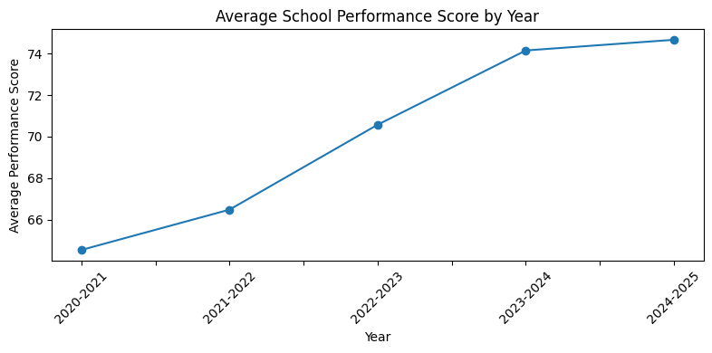

```python
import matplotlib.pyplot as plt

# Plot the change in the average performance score throughout the  school years.
avg_performance_per_year.plot(marker="o", figsize=(8, 4))

# Label the graph
plt.title("Average School Performance Score by Year")
plt.xlabel("Year")
plt.ylabel("Average Performance Score")
plt.xticks(rotation=45)
plt.tight_layout()
plt.show()
```

## Exploratory Data Analysis (EDA)

In this section we combine both datasets and explore trends, distributions, and relationships in the data to inform our modeling decisions.

```python
# Combine pre- and post-COVID datasets into one unified DataFrame
# df_pre_covid has: school_name, school_year, school_performance_score_sps
# df_postcovid has all of the above plus additional columns (progress_index, school_type, etc.)
df_all = pd.concat([df_pre_covid, df_postcovid], ignore_index=True)

# Verify school_year is consistent (string format) across both datasets
df_all["school_year"] = df_all["school_year"].astype(str)

print("Combined dataset shape:", df_all.shape)
print("\nSchool years present:")
print(sorted(df_all["school_year"].unique()))
```

```
Combined dataset shape: (8141, 18)

School years present:
['2015-2016', '2016-2017', '2017-2018', '2018-2019', '2019-2020', '2020-2021', '2021-2022', '2022-2023', '2023-2024', '2024-2025']
```

### Missing Data Analysis

Before conducting exploratory analysis and modeling, we examine missing data across the combined dataset. This helps ensure that our results are not biased and informs how we handle incomplete observations in later steps.

```python
missing_table = pd.DataFrame({
    "Missing Values": df_all.isnull().sum(),
    "Percent Missing": (df_all.isnull().sum() / len(df_all)) * 100
}).sort_values(by="Percent Missing", ascending=False)

missing_table
```

|  | Missing Values | Percent Missing |
| --- | --- | --- |
| graduation_rate | 8011 | 98.403145 |
| nola-ps_assessment_index | 7927 | 97.371330 |
| assessment_index_letter_grade | 7870 | 96.671171 |
| nola-ps_progress_index | 7862 | 96.572903 |
| nola-ps_top_growth_% | 7862 | 96.572903 |
| progress_index_letter_grade | 7855 | 96.486918 |
| sps_letter_grade | 7854 | 96.474635 |
| assessment_index | 7808 | 95.909593 |
| %_attaining_top_growth | 7791 | 95.700774 |
| progress_index | 7791 | 95.700774 |
| grade_configuration | 7789 | 95.676207 |
| site_code | 7789 | 95.676207 |
| school_type | 7789 | 95.676207 |
| subgroup | 7789 | 95.676207 |
| domain | 7789 | 95.676207 |
| school_name | 0 | 0.000000 |
| school_year | 0 | 0.000000 |
| school_performance_score_sps | 0 | 0.000000 |

Most missing values occur in variables that are not present in both datasets, such as progress_index, which is only available in the post-COVID data. Since our models rely only on variables available at the time of analysis, we handle missing data by filtering to complete cases when necessary rather than imputing values.

### School Performance Before and After COVID

This line graph plots the average SPS across all schools for every school year from 2015–2016 through 2024–2025. A dashed vertical line marks the start of COVID-19 (2019–2020). This is the central visualization of our analysis — it allows us to directly compare the trajectory of school performance before, during, and after the pandemic disruption.

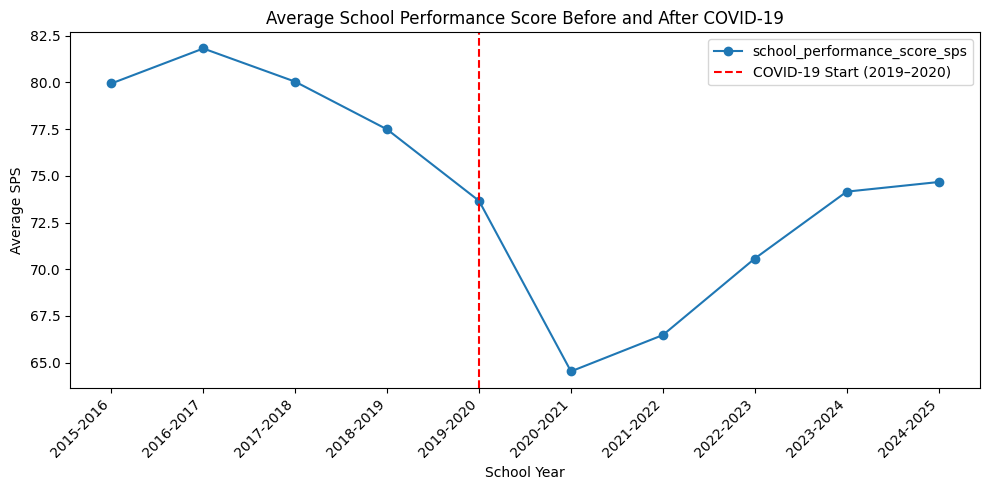

```python
# Calculate average SPS per school year across the combined dataset
avg_all = df_all.groupby("school_year")["school_performance_score_sps"].mean().sort_index()

# Get the integer position of the COVID start year for the vertical line
years_list = list(avg_all.index)
covid_index = years_list.index("2019-2020") if "2019-2020" in years_list else None

fig, ax = plt.subplots(figsize=(10, 5))
avg_all.plot(marker="o", ax=ax)
if covid_index is not None:
    ax.axvline(x=covid_index, color="red", linestyle="--", label="COVID-19 Start (2019–2020)")
ax.legend()
ax.set_title("Average School Performance Score Before and After COVID-19")
ax.set_xlabel("School Year")
ax.set_ylabel("Average SPS")
plt.xticks(range(len(years_list)), years_list, rotation=45, ha="right")
plt.tight_layout()
plt.show()
```

### Average School Performance Scores Before and After COVID-19

This bar chart compares the average School Performance Scores (SPS) between the pre-COVID (2015–2019) and post-COVID (2020–2025) periods. While post-COVID scores appear to be approaching pre-pandemic levels, they do not fully exceed them, suggesting a partial but incomplete recovery. This pattern indicates that although schools have made progress in regaining performance, the long-term impact of COVID-19 may still be present.

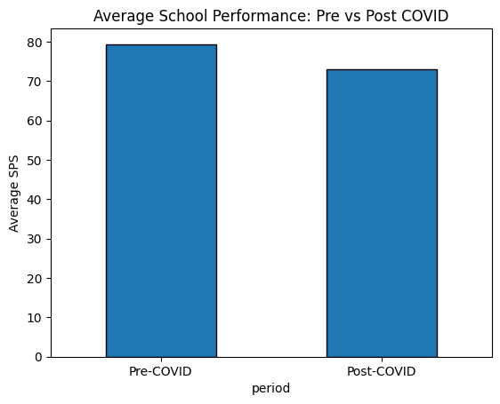

```python
df_all["period"] = df_all["school_year"].apply(
    lambda x: "Pre-COVID" if x < "2019-2020" else "Post-COVID"
)

avg_period = df_all.groupby("period")["school_performance_score_sps"].mean()

# Fix order
avg_period = avg_period.reindex(["Pre-COVID", "Post-COVID"])

avg_period.plot(kind="bar", edgecolor="black")
plt.title("Average School Performance: Pre vs Post COVID")
plt.ylabel("Average SPS")
plt.xticks(rotation=0)
plt.show()
```

### SPS Distribution by School Year (Box Plot)

This box plot shows the spread of individual school performance scores for each post-COVID school year. Unlike the line graph of averages, the box plot reveals the median, interquartile range, and outliers for each year. This lets us see not only whether the average improved, but whether the improvement was broad-based or concentrated in a few high-performing schools.

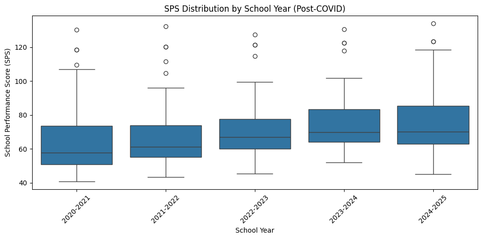

```python
plt.figure(figsize=(10, 5))
sns.boxplot(
    data=df_postcovid,
    x="school_year",
    y="school_performance_score_sps"
)
plt.title("SPS Distribution by School Year (Post-COVID)")
plt.xlabel("School Year")
plt.ylabel("School Performance Score (SPS)")
plt.xticks(rotation=45)
plt.tight_layout()
plt.show()
```

### Summary Statistics Table: SPS by School Year

This cross-tabulation of summary statistics (mean, median, standard deviation, count) by school year gives a precise numerical picture of how SPS has changed over time. The median is especially useful here alongside the mean, as it is less sensitive to outlier schools like Benjamin Franklin High School.

```python
# Group by school year and compute measures of central tendency and spread
sps_summary = df_postcovid.groupby("school_year")["school_performance_score_sps"].agg(
    count="count",
    mean="mean",
    median="median",
    std="std",
    min="min",
    max="max"
).round(2)

print("Summary Statistics: SPS by School Year")
sps_summary
```

```
Summary Statistics: SPS by School Year
```

| school_year | count | mean | median | std | min | max |
| --- | --- | --- | --- | --- | --- | --- |
| 2020-2021 | 65 | 64.53 | 57.8 | 19.41 | 40.9 | 130.3 |
| 2021-2022 | 70 | 66.48 | 61.2 | 18.38 | 43.3 | 132.4 |
| 2022-2023 | 71 | 70.57 | 67.1 | 16.76 | 45.4 | 127.5 |
| 2023-2024 | 73 | 74.15 | 70.0 | 16.27 | 52.1 | 130.6 |
| 2024-2025 | 73 | 74.67 | 70.1 | 17.71 | 45.0 | 133.9 |

### Relationship Between Student Progress and School Performance

This scatterplot examines the relationship between a school's progress index (a measure of how much students grew academically during the year) and its overall SPS. A positive relationship here would suggest that student growth is a meaningful driver of school performance — and would motivate the use of progress index as a predictor in our regression model. Each point is a school in a given year, colored by school year.

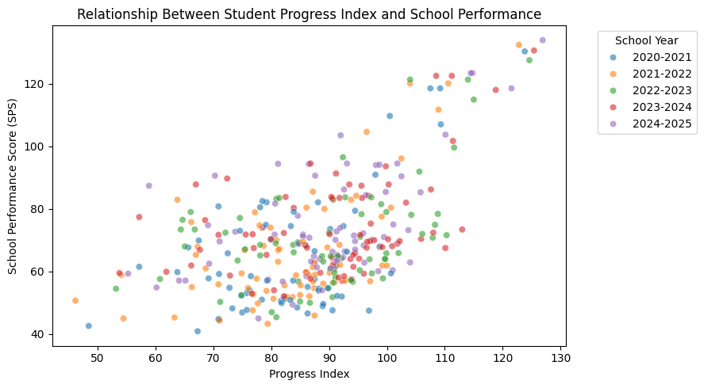

```python
# Filter to rows that have both progress_index and SPS available
df_analysis = df_postcovid.dropna(subset=["progress_index", "school_performance_score_sps"])

plt.figure(figsize=(9, 5))
sns.scatterplot(
    data=df_analysis,
    x="progress_index",
    y="school_performance_score_sps",
    hue="school_year",
    alpha=0.6
)
plt.title("Relationship Between Student Progress Index and School Performance")
plt.xlabel("Progress Index")
plt.ylabel("School Performance Score (SPS)")
plt.legend(title="School Year", bbox_to_anchor=(1.05, 1), loc="upper left")
plt.tight_layout()
plt.show()
```

### Post-COVID Progress vs. Performance by School Type

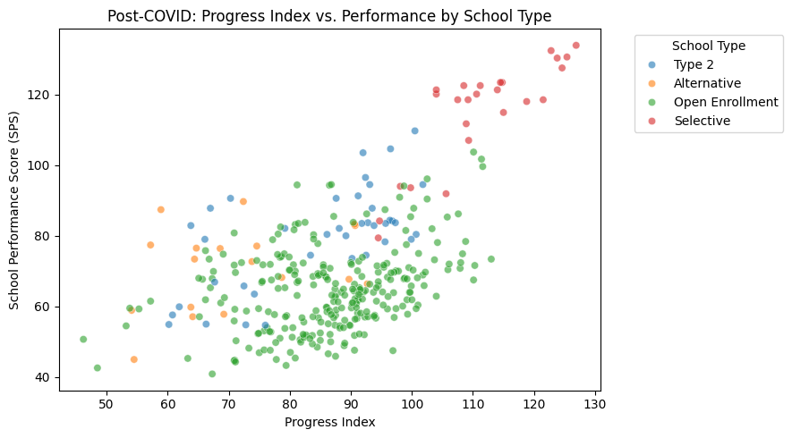

```python
if "school_type" in df_analysis.columns:
    plt.figure(figsize=(9, 5))
    sns.scatterplot(
        data=df_analysis,
        x="progress_index",
        y="school_performance_score_sps",
        hue="school_type",
        alpha=0.6
    )
    plt.title("Post-COVID: Progress Index vs. Performance by School Type")
    plt.xlabel("Progress Index")
    plt.ylabel("School Performance Score (SPS)")
    plt.legend(title="School Type", bbox_to_anchor=(1.05, 1), loc="upper left")
    plt.tight_layout()
    plt.show()
else:
    print("'school_type' column not found in dataset — skipping this plot.")
```

The scatterplots above show a positive relationship between student progress and overall school performance. Schools with higher progress index scores tend to have higher SPS values. In the post-COVID years, this relationship remains visible, suggesting that recovery in school performance is closely tied to student learning growth. This indicates that differences in recovery across schools may be driven by how effectively they supported student progress during and after the pandemic.

## Model Questions

The exploratory data analysis above supports the following two modeling approaches:

### Model Question 1: Predicting School Performance from Student Progress

**Question:** Is student progress index a significant predictor of school performance score (SPS) in post-COVID New Orleans schools?

- **Dependent Variable:** `school_performance_score_sps`
- **Independent Variable:** `progress_index`
- **Methodology:** Simple linear regression. We will fit a least-squares regression line, report the coefficient and R² value, and evaluate statistical significance via the p-value of the slope.
- **Evaluation:** R² (proportion of variance explained), RMSE (average prediction error), and a residual plot to check for violations of linearity.
- **EDA Support:** Graph 6 shows a clear positive relationship between `progress_index` and SPS, suggesting that a linear model is a reasonable starting point.

### Model Question 2: Impact of COVID-19 on School Performance

**Question:** Did COVID-19 cause a statistically significant decline in average school performance scores in New Orleans public schools?

### Linear Regression Model: Predicting SPS from Progress Index

```python
from sklearn.linear_model import LinearRegression
from sklearn.metrics import r2_score, mean_squared_error
from scipy.stats import linregress
import numpy as np

# Remove missing values
df_model = df_postcovid.dropna(
    subset=["progress_index", "school_performance_score_sps"]
)

X = df_model[["progress_index"]]
y = df_model["school_performance_score_sps"]

# Fit model
model = LinearRegression()
model.fit(X, y)

# Predictions
y_pred = model.predict(X)

# Metrics
r2 = r2_score(y, y_pred)
rmse = np.sqrt(mean_squared_error(y, y_pred))

print("Slope:", model.coef_[0])
print("Intercept:", model.intercept_)
print("R²:", r2)
print("RMSE:", rmse)
```

```
Slope: 0.7181966868870339
Intercept: 7.444197999711044
R²: 0.30339430238665344
RMSE: 15.082545772683781
```

```python
# Perform linear regression to measure the relationship between student progress index and school performance score (SPS)
slope, intercept, r_value, p_value, std_err = linregress(
    df_model["progress_index"],
    df_model["school_performance_score_sps"]
)

# Display the p-value
print("P-value:", p_value)
```

```
P-value: 3.68784430989197e-29
```

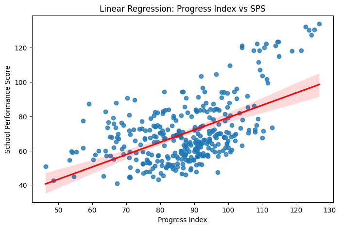

```python
# @title Visualization
plt.figure(figsize=(8,5))

sns.regplot(
    data=df_model,
    x="progress_index",
    y="school_performance_score_sps",
    line_kws={"color": "red"}
)

plt.title("Linear Regression: Progress Index vs SPS")
plt.xlabel("Progress Index")
plt.ylabel("School Performance Score")
plt.show()
```

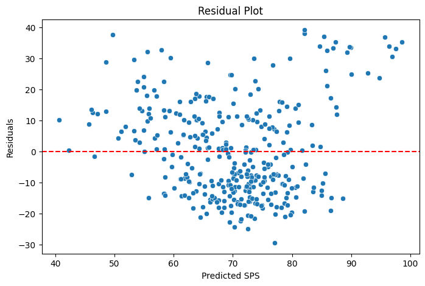

```python
# Calculate the prediction errors made by the model
residuals = y - y_pred

# Plot
plt.figure(figsize=(8,5))
sns.scatterplot(x=y_pred, y=residuals)

plt.axhline(0, color='red', linestyle='--')

plt.title("Residual Plot")
plt.xlabel("Predicted SPS")
plt.ylabel("Residuals")
plt.show()
```

### Statistical Test: Comparing Pre- and Post-COVID SPS

```python
from scipy.stats import ttest_ind

# Separate SPS into pre-COVID and post-COVID groups
pre_scores = df_all[
    df_all["period"] == "Pre-COVID"
]["school_performance_score_sps"]

post_scores = df_all[
    df_all["period"] == "Post-COVID"
]["school_performance_score_sps"]

# Perform an independent two-sample t-test
t_stat, p_value = ttest_ind(
    pre_scores,
    post_scores,
    equal_var=False
)

# Display
print("T-statistic:", t_stat)
print("P-value:", p_value)
```

```
T-statistic: 12.514975337630377
P-value: 4.442416434694247e-35
```

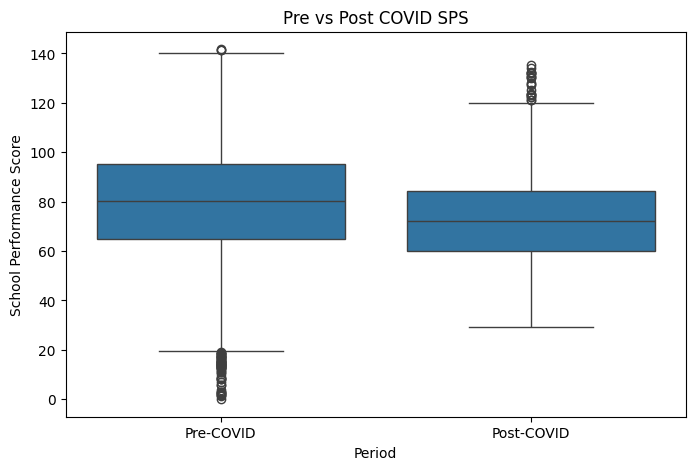

```python
# @title Visualization
plt.figure(figsize=(8,5))

sns.boxplot(
    data=df_all,
    x="period",
    y="school_performance_score_sps"
)

plt.title("Pre vs Post COVID SPS")
plt.xlabel("Period")
plt.ylabel("School Performance Score")
plt.show()
```

The t-test results indicate whether the difference between pre- and post-COVID school performance scores is statistically significant. A small p-value would suggest that the observed decline in SPS is unlikely to be due to random variation alone. This supports the conclusion that COVID-19 had a measurable impact on school performance outcomes in New Orleans public schools.

### Segmented Regression Around Covid-19

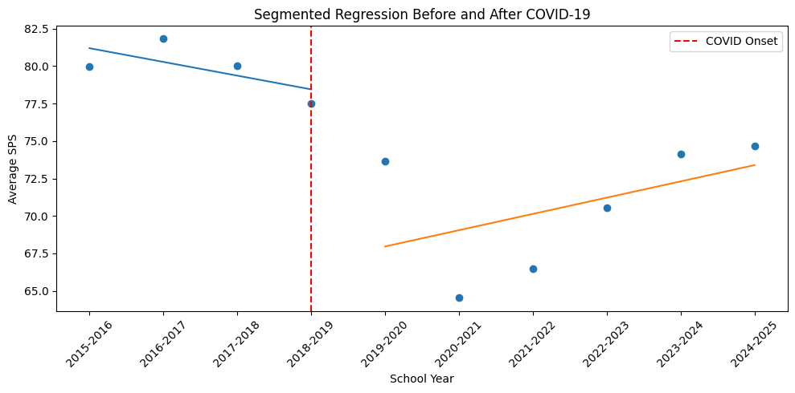

```python
from scipy.stats import linregress

# Create numeric year index
avg_all_df = avg_all.reset_index()
avg_all_df.columns = ["school_year", "avg_sps"]
avg_all_df["time"] = range(len(avg_all_df))

# Split pre/post COVID
pre = avg_all_df[avg_all_df["school_year"] < "2019-2020"]
post = avg_all_df[avg_all_df["school_year"] >= "2019-2020"]

# Separate regressions
pre_reg = linregress(pre["time"], pre["avg_sps"])
post_reg = linregress(post["time"], post["avg_sps"])

# Plot
plt.figure(figsize=(10,5))

plt.scatter(avg_all_df["time"], avg_all_df["avg_sps"])

# Pre trend line
plt.plot(
    pre["time"],
    pre_reg.intercept + pre_reg.slope * pre["time"],
)

# Post trend line
plt.plot(
    post["time"],
    post_reg.intercept + post_reg.slope * post["time"],
)

plt.axvline(
    x=pre["time"].max(),
    color="red",
    linestyle="--",
    label="COVID Onset"
)

plt.xticks(
    avg_all_df["time"],
    avg_all_df["school_year"],
    rotation=45
)

plt.title("Segmented Regression Before and After COVID-19")
plt.xlabel("School Year")
plt.ylabel("Average SPS")
plt.legend()
plt.tight_layout()
plt.show()
```

The segmented regression shows that SPS trends differed before and after the onset of COVID-19. The slope of the post-COVID regression line suggests a recovery trend, while the discontinuity near 2019–2020 indicates a structural disruption associated with the pandemic. Although this analysis does not prove causality, it provides evidence that COVID-19 corresponded with a meaningful shift in academic performance trends.

## Conclusions

This analysis examined the impact of COVID-19 on school performance in New Orleans public schools using pre-pandemic (2015–2019) and post-pandemic (2020–2025) data. Through exploratory analysis and statistical modeling, we evaluated both overall performance trends and the role of student growth in recovery.

The linear regression results show a clear positive relationship between student progress index and school performance score (SPS). The statistically significant p-value suggests that student growth is an important predictor of school performance, with higher progress associated with higher SPS in the post-COVID period.

The t-test results indicate that the decline in performance at the onset of COVID-19 is statistically significant, supporting the conclusion that the pandemic had a measurable negative impact on school performance rather than the change being due to random variation.

The segmented regression further shows a structural break in trends around 2019–2020. While performance declines sharply at the start of COVID-19, the post-COVID trend shows signs of recovery, though not at the same trajectory as before the pandemic.

Overall, these results suggest that New Orleans schools have made progress in recovering from pandemic-related disruptions, but the effects of COVID-19 are still present and recovery remains ongoing and uneven.

### Limitations

Additionally, not all variables are consistently available across time periods. For example, the progress index only exists in the post-COVID data, and changes in SPS calculations over time may affect direct comparisons across years.

Finally, the models used are relatively simple and do not account for other influencing factors such as school funding, demographics, or policy changes. Future work could incorporate additional variables or more advanced models to better understand differences in recovery across schools.

```python
# 1. Save notebook
from google.colab import _message
import json

nb = _message.blocking_request('get_ipynb')['ipynb']
with open('/content/dsproject.ipynb', 'w') as f:
    json.dump(nb, f)
```

```python
# 2. Convert to HTML
!jupyter nbconvert --to html /content/dsproject.ipynb
```

```python
# 3. Download
from google.colab import files
files.download('/content/dsproject.html')
```